# 04_Exploratory_Data_Analysis

## Load Packages

These are the packages that have been used throughout the following document: `here`, `tidyverse`, `lubridate`, `knitr`

*other packages will be loaded as needed*

## Reading data and combining

```r
# transformed independent variable data
ivd <-
  readRDS(
    here(
      "Data",
      "JACSIS2023",
      "processed",
      "transformed_independent_variable_data.RDS"
      )
    )

# transformed covid data
cov <-
  readRDS(
    here(
      "Data",
      "JACSIS2023",
      "processed",
      "transformed_covid_data.RDS"
    )
  )

# transformed influenza data
inf <-
  readRDS(
    here(
      "Data",
      "JACSIS2023",
      "processed",
      "transformed_influenza_data.RDS"
    )
  )


# Factorising the data

cov <- cov |>
  mutate(
    # factorise cov dosage
    covid_coverage_dosage = factor(covid_coverage_dosage, levels = c(0, 1, 2, 3))
  )

#cov <- cov |>
#  mutate(
    # factorise cov age coverage
#    covid_coverage_age = factor(covid_coverage_age, levels = c(0, 1, 2))
#  )

inf <- inf |>
  mutate(
    # factorise inf dosage
    influenza_coverage_dosage = factor(influenza_coverage_dosage, levels = c(0, 1, 2)))

#inf <- inf |>
#  mutate(
    # factorise inf age coverage
#    influenza_coverage_age = factor(influenza_coverage_age, levels = c(0, 1, 2))
#  )


# Creating data frames for bivariate and multivariate analysis
# influenza and independent variable data
inf_ivd <- bind_cols(inf, ivd)

# covid and independent variable data
cov_ivd <- bind_cols(cov, ivd)
```

## Influenza data

### Distribution of coverage by number of doses and the degree of coverage (since october 2022)

**By degree of coverage**

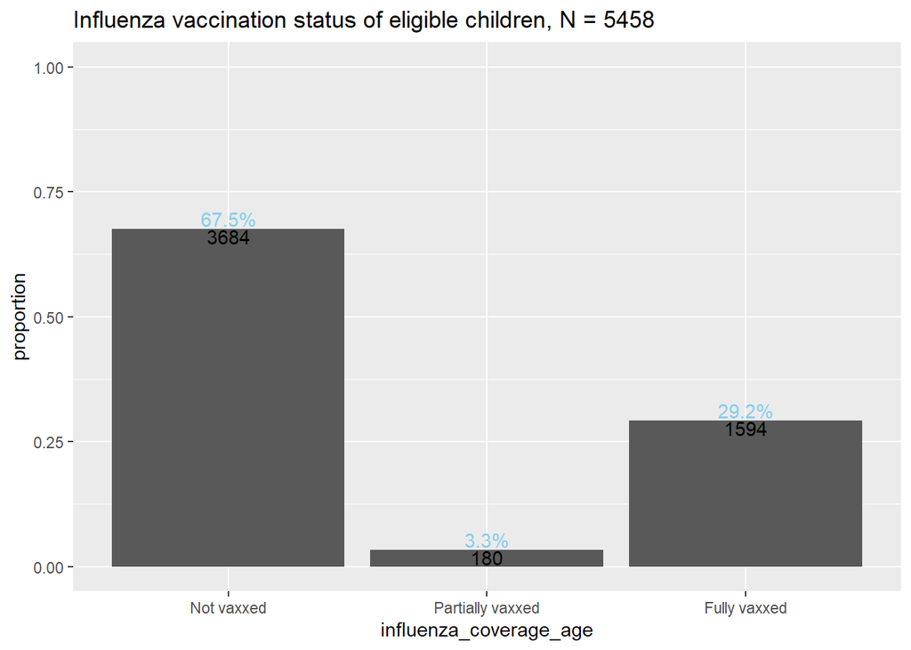

```r
  inf |>
    filter(!is.na(influenza_coverage_age)) |>
    summarise(individuals = n(), .by = influenza_coverage_age) |>
    mutate(proportion = individuals / sum(individuals)) |>
    arrange(influenza_coverage_age) |>
    mutate(
      influenza_coverage_age = factor(
        case_when(
        influenza_coverage_age == 0 ~ "Not vaxxed",
        influenza_coverage_age == 1 ~ "Partially vaxxed",
        influenza_coverage_age == 2 ~ "Fully vaxxed"
        ),
        levels = c("Not vaxxed", "Partially vaxxed", "Fully vaxxed")
      )
    ) |>

    ggplot(aes(x = influenza_coverage_age, y = proportion)) +
    geom_col() +
    ylim(0, 1) +
    geom_text(aes(label = individuals), vjust = 1.0) +
    ggtitle(
      paste(
        "Influenza vaccination status of eligible children, N =",
        sum(!is.na(inf$influenza_coverage_age))
        )
      ) +
    geom_text(aes(label = paste(signif(proportion*100, 3), "%", sep = "")), vjust = -0.2 , colour = "skyblue")
```

**By number of doses**

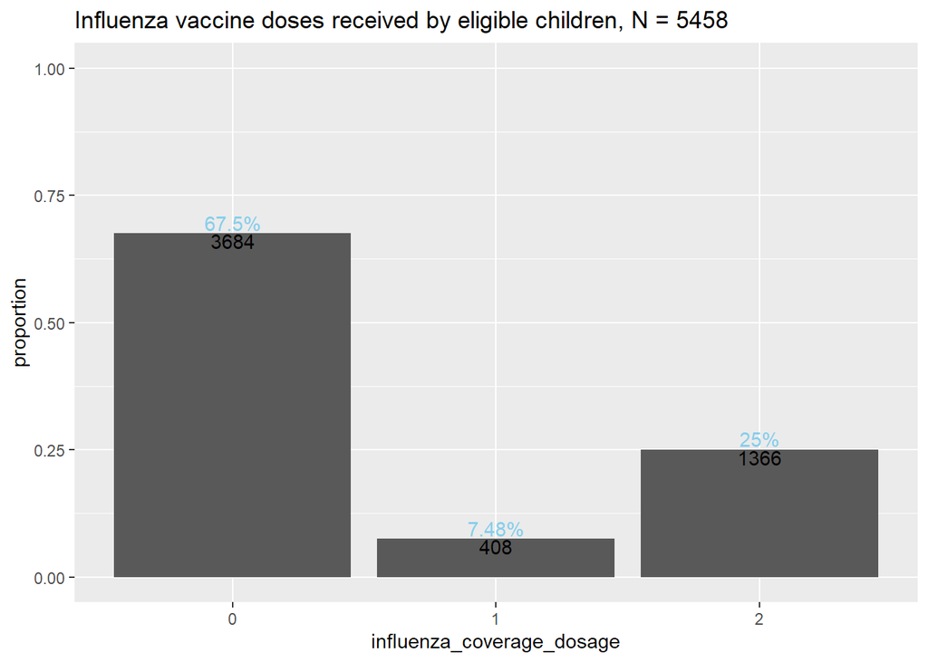

```r
  inf |>
    filter(!is.na(influenza_coverage_dosage)) |>
    summarise(individuals = n(), .by = influenza_coverage_dosage) |>
    mutate(proportion = individuals / sum(individuals)) |>
    arrange(influenza_coverage_dosage) |>

    ggplot(aes(x = influenza_coverage_dosage, y = proportion)) +
    geom_col() +
    ylim(0, 1) +
    geom_text(aes(label = individuals), vjust = 1.0) +
    ggtitle(
      paste(
        "Influenza vaccine doses received by eligible children, N =",
        sum(!is.na(inf$influenza_coverage_dosage))
        )
      ) +
    geom_text(aes(label = paste(signif(proportion*100, 3), "%", sep = "")), vjust = -0.2 , colour = "skyblue")
```

A majority of the children (68%) who are eligible for the influenza vax have not receieved the vaccine at all (i.e. 0 doses or Not vaxxed). However, within the children who have receieved at least one dose of the vaccine (~32%), a much greater proportion of them are considered fully vaxxed than being partially vaxxed (a ratio of 10:1).

This is supported by data on the number of doses received, the ratio of individuals who have received 2 doses as compared to 1 dose is roughly 3:1 (25:7.5). The discrepnacy in ratios can be explained by children below the age of 5 being considered fully vaxxed individuals upon receiving 1 or more doses of the influenza vax

## Covid data

### Distribution of coverage by number of doses and the degree of coverage (since october 2022)

**By degree of coverage**

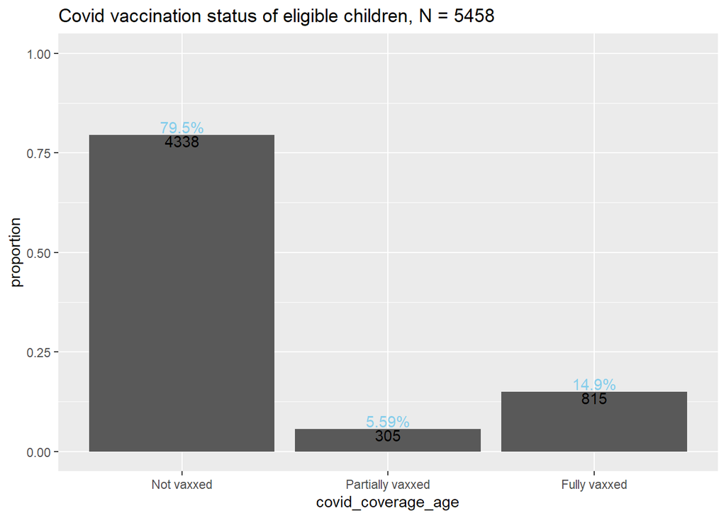

```r
  cov |>
    filter(!is.na(covid_coverage_age)) |>
    summarise(individuals = n(), .by = covid_coverage_age) |>
    mutate(proportion = individuals / sum(individuals)) |>
    arrange(covid_coverage_age) |>
    mutate(
      covid_coverage_age = factor(
        case_when(
        covid_coverage_age == 0 ~ "Not vaxxed",
        covid_coverage_age == 1 ~ "Partially vaxxed",
        covid_coverage_age == 2 ~ "Fully vaxxed"
        ),
        levels = c("Not vaxxed", "Partially vaxxed", "Fully vaxxed")
      )
    ) |>

    ggplot(aes(x = covid_coverage_age, y = proportion)) +
    geom_col() +
    ylim(0, 1) +
    geom_text(aes(label = individuals), vjust = 1.0) +
    ggtitle(
      paste(
        "Covid vaccination status of eligible children, N =",
        sum(!is.na(cov$covid_coverage_age))
        )
      ) +
    geom_text(aes(label = paste(signif(proportion*100, 3), "%", sep = "")), vjust = -0.2 , colour = "skyblue")
```

**By number of doses**

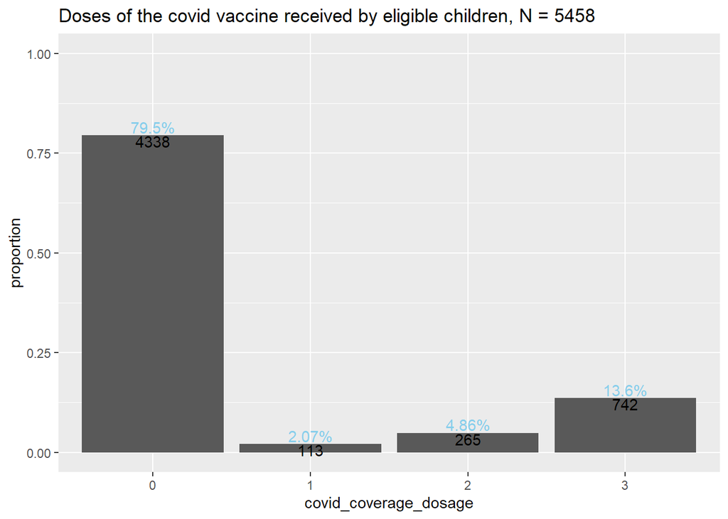

```r
  cov |>
    filter(!is.na(covid_coverage_dosage)) |>
    summarise(individuals = n(), .by = covid_coverage_dosage) |>
    mutate(proportion = individuals / sum(individuals)) |>
    arrange(covid_coverage_dosage) |>

    ggplot(aes(x = covid_coverage_dosage, y = proportion)) +
    geom_col() +
    ylim(0, 1) +
    geom_text(aes(label = individuals), vjust = 1.0) +
    ggtitle(
      paste(
        "Doses of the covid vaccine received by eligible children, N =",
        sum(!is.na(cov$covid_coverage_dosage))
        )
      ) +
    geom_text(aes(label = paste(signif(proportion*100, 3), "%", sep = "")), vjust = -0.2 , colour = "skyblue")
```

The data on covid vaccinations tells a similar story to that of influenza vaccinations. Namely, the proportion of eligible children who are not vaxxed at all remains high at 80% of the children body. However, the proportion of individuals who are partially vaccinated – less than 3 doses for individuals over the age of 5 – is significantly higher (partial:full = 1:3) than that for those who received the influenza vaccine (partial:full = 1:10).

Referencing the number of doses of the covid vaccine received by individuals, we note that 13.6% of the eligible children received 3 doses of the covid vaccine, 1.3% lower than the 14.9% of children who are fully vaxxed – this is explained by children under 5y/o being classified as fully vaccinated as long as they have 1 or more doses of the covid vaccine due to variances in the vaccination schedule of covid vacccines for that age group. Note that majority (85%) of the 5.6% children who are partially vaccinated received 2 doses, 4.8% of all eligible children.

*Why are there more children who are partially vaccinated for covid as opposed to the influenza vaccination?*

## Multivariate analysis

### Independent variables

Package used: `GGally` for pairs plots?

## Bivariate analysis

### Independent variables

Questions to be asked

## Number of individuals

### Total number of individuals

The following is a breakdown of the number of households according to number of individuals per household

```r
ivd |>

  # group number of households and number of households with children of
  # interest by individuals per household
  summarise(
    households = n(),
    households_w_COI = sum(child_of_interest),
    percentage_w_COI = signif((households_w_COI / households) * 100, 2),
    .by = household_total
  ) |>

  # arrange in ascending order of individuals per household
  arrange(.by = household_total) |>
  rename(individuals = household_total) -> households_by_indivs


  # display a transposed table
  households_by_indivs |>
  t() |>
  as.data.frame() |>
   kable(col.names = NULL)
```

| individuals | 1 | 2 | 3 | 4 | 5 | 6 | 7 | 8 | 9 | 10 | 11 | 12 | 15 | 21 | 25 |
| --- | --- | --- | --- | --- | --- | --- | --- | --- | --- | --- | --- | --- | --- | --- | --- |
| households | 7995 | 10901 | 7149 | 5003 | 1429 | 381 | 97 | 31 | 5 | 3 | 1 | 1 | 1 | 1 | 2 |
| households_w_COI | 0 | 109 | 2244 | 2378 | 673 | 174 | 39 | 11 | 4 | 1 | 1 | 0 | 0 | 0 | 2 |
| percentage_w_COI | 0 | 1 | 31 | 48 | 47 | 46 | 40 | 35 | 80 | 33 | 100 | 0 | 0 | 0 | 100 |

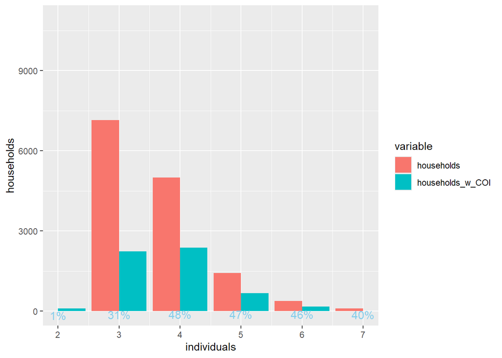

```r
  # bar and line plot
family_overview <-
  households_by_indivs |>
    melt(id = 'individuals') |>
    rename(households = value) -> melted_households_by_indivs
    ggplot() +
    geom_col(
      mapping = aes(x = individuals, y = households, fill = variable),
      data = melted_households_by_indivs[1:30, ],
      position = "dodge"
    ) +
    #geom_text(
      #mapping = aes(x = individuals, y = households, label = households),
      #data = melted_households_by_indivs[1:30, ],
      #vjust = -0.5, size = 2.0
    #) +
    geom_text(
      aes(x = individuals, y = households, label = paste(households, "%", sep = "" )),
      melted_households_by_indivs[30:45, ],
      vjust = 1.0, size = 4.0, colour = "skyblue"
    ) + xlim(2,7)
```

Responses from households of 3 to 5 people posses the majority of children of interest. Households comprise of 2 individuals had very little responses with a child of interest which could be attributed to there being less single-child parents.

To examine how the number of individuals in a household affects the children of interest then, we should primarily be looking at households of at least 2 individuals (children of interest = 109), and up to 7 people (children of interest = 39).

*Does the number of individuals in a household affect*

Breakdown of the number of households by household size – for those with covid vaccination data

```r
cov_ivd |>
  filter(household_total > 1 & !is.na(covid_coverage_age)) |>
  group_by(household_total) |>
  summarise(count = n()) |>
  kable(format = "html")
```

| household_total | count |
| --- | --- |
| 2 | 109 |
| 3 | 2078 |
| 4 | 2370 |
| 5 | 672 |
| 6 | 173 |
| 7 | 38 |
| 8 | 11 |
| 9 | 3 |
| 10 | 1 |
| 11 | 1 |
| 25 | 2 |

*1. The child’s covid vaccination status*

```r
# determine the proportion of individuals who are not, partially and fully vaccinated
# for households of each size
covage_by_total <- cov_ivd |>
   filter(household_total > 1 & !is.na(covid_coverage_age)) |>
   group_by(household_total, covid_coverage_age) |>
   summarise(count = n()) |>
   ggplot() +
   geom_col(
     aes(x = household_total, y = count, fill = covid_coverage_age),
     position = "fill"
   ) +
   ylab("Proportion")
   scale_fill_hue(labels = c("not vaxxed", "partially vaxxed", "fully vaxxed"))
```

[output not shown]

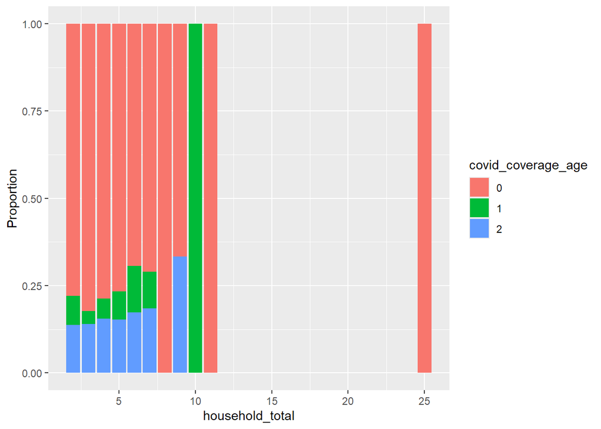

```r
# print full graph
covage_by_total
```

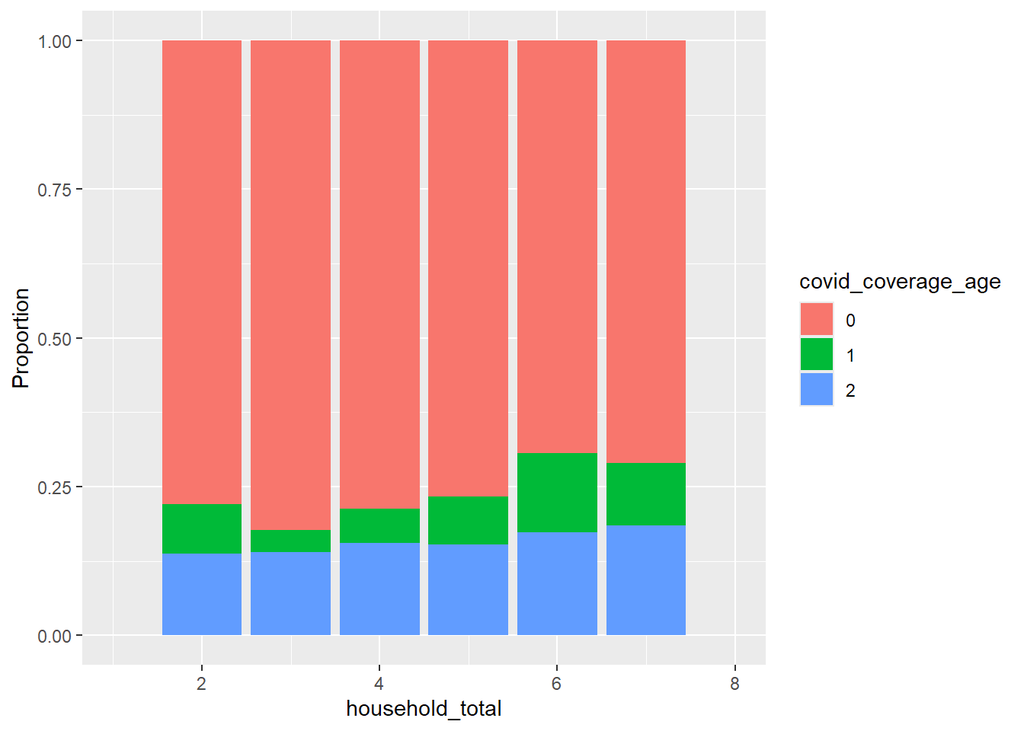

```r
# limit the same plot to households of 2 to 7 individuals
covage_by_total + xlim(1,8)
```

For household sizes of 2 to 7 individuals, we see a positive linear relationship between household size and being fully vaccinated. The apparent continuation of this trend with households of size 9 is deceptive as it is due to the small sample size of households of 9 individuals (n = 3)

*2. The number of doses of the covid vaccine the child receives*

*Following data on the degree of covid coverage by total household size, we limit the range of household sizes to household sizes of sufficiently large (n >= 30) counts.

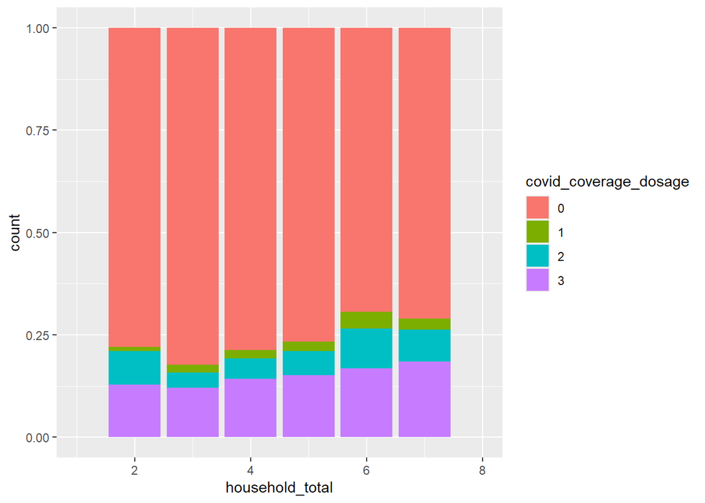

```r
# determine the proportion of individuals who receive 0 to 3 doses
# for households of each size
cov_ivd |>

   # stratify by household size and doses received
   filter(household_total > 1 & !is.na(covid_coverage_dosage)) |>
   # factorise dosage
   mutate(
    covid_coverage_dosage = factor(covid_coverage_dosage)
   ) |>
   group_by(household_total, covid_coverage_dosage) |>

   # count the number of children in each category
   summarise(count = n()) |>
   ggplot() +
   geom_col(
     aes(x = household_total, y = count, fill = covid_coverage_dosage),
     position = "fill"
   ) +
   xlim(1,8)
```

Using simple linear regression to test the effect of an increasing number of household members on the proportions of individuals receiving 0 to 3 doses of the covid vaccine respectively.

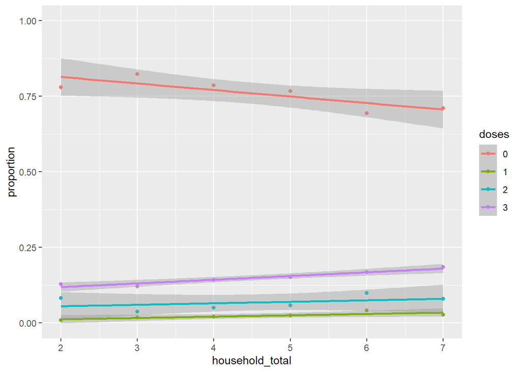

```r
cov_ivd |>
     mutate(covid_coverage_dosage = factor(covid_coverage_dosage)) |>

     # stratify by household size and doses received
     filter(household_total > 1 & !is.na(covid_coverage_dosage)) |>
     group_by(household_total, covid_coverage_dosage) |>

     # count the number of children in each category
     summarise(count = n()) |>
     reframe(doses = covid_coverage_dosage, proportion = count/sum(count)) |>
     ggplot(aes(x = household_total, y = proportion, colour = doses)) +
     xlim(2,7) +
     geom_point() +
     geom_smooth(method = "lm")
```

There is a positive linear relationship between total household size and the number of individuals receiving 1 & 3 doses of the covid vaccine.

This is accounted for by the negative linear relationship between total household size and the number of individuals receiving 0 doses of the covid vaccine – indicating that more invidiuals who were previously unvaccinated were getting vaccinated.

However, there was no significant relationship between total household size and the proportion of individuals who received 2 doses of the covid vaccine.

*3.the child’s (influenza) vaccination status* Breakdown of the number of households by household size – for those with influenza vaccination data

```r
inf_ivd |>
  filter(household_total > 1 & !is.na(influenza_coverage_age)) |>
  group_by(household_total) |>
  summarise(count = n())
```

```
# A tibble: 11 × 2
   household_total count
             <int> <int>
 1               2   109
 2               3  2078
 3               4  2370
 4               5   672
 5               6   173
 6               7    38
 7               8    11
 8               9     3
 9              10     1
10              11     1
11              25     2
```

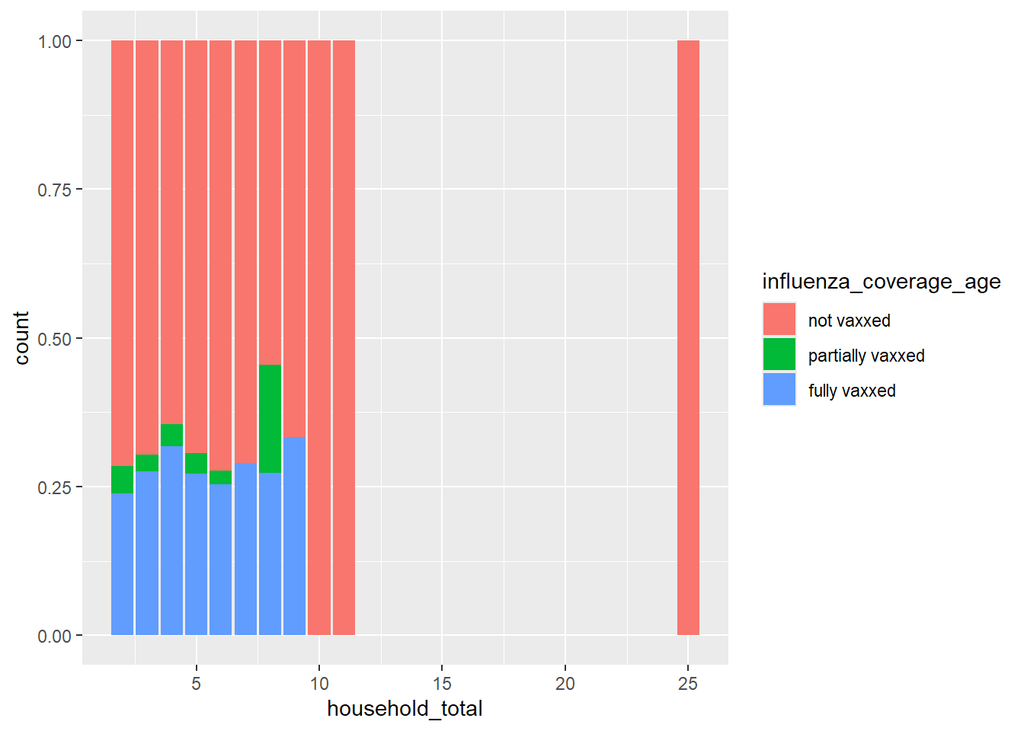

```r
# determine the proportion of individuals who are not, partially and fully vaccinated
# for households of each size
infage_by_total <- inf_ivd |>
   filter(household_total > 1 & !is.na(influenza_coverage_age)) |>
   group_by(household_total, influenza_coverage_age) |>
   summarise(count = n()) |>
   ggplot() +
   geom_col(
     aes(x = household_total, y = count, fill = influenza_coverage_age),
     position = "fill"
   ) +
   scale_fill_hue(labels = c("not vaxxed", "partially vaxxed", "fully vaxxed"))

# print full graph
infage_by_total
```

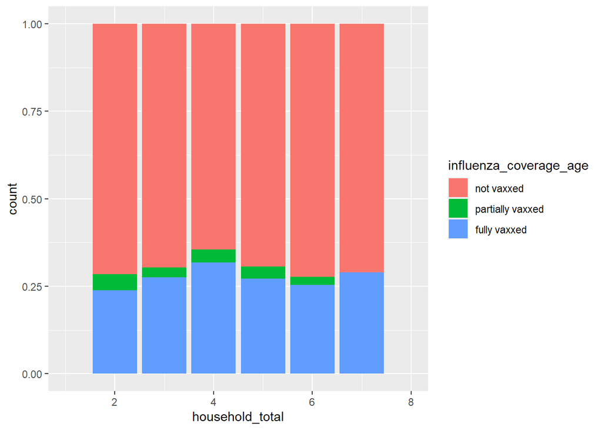

```r
# limit the same plot to households of 2 to 7 individuals
 infage_by_total + xlim(1,8)
```

We limit the range of observations to households of sizes from 2 to 7 people such that the sample for each household size is sufficiently large (n >= 30).

Whilst it may appear that the proportion of individuals who get fully vaccinated increases with an increasing household size, this does not hold true once we limit the range of observations to households of sizes from 2 to 7 people such that the sample for each household size is sufficiently large (n >= 30).

The proportion of children of interest becoming fully vaccinated with the influenza vaccine fluctuates with the total number of individuals in a household. This deviates from the trend, where the proportion of individuals becoming fully vaccinated increased as the total number of individuals in a household increased, shown with the covid vaccine.

```
-   the number of doses of the influenza vaccine the child receives
```

*Following data on the degree of influenza coverage by total household size, we limit the range of household sizes to household sizes of sufficiently large (n >= 30) counts.

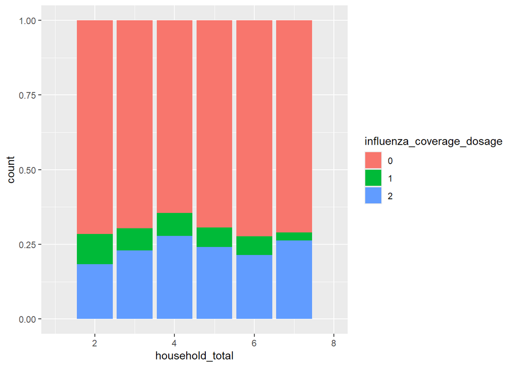

```r
# determine the proportion of individuals who receive 0 to 3 doses
# for households of each size
inf_ivd |>

   # stratify by household size and doses received
   filter(household_total > 1 & !is.na(influenza_coverage_dosage)) |>
   mutate(influenza_coverage_dosage = factor(influenza_coverage_dosage)) |>
   group_by(household_total, influenza_coverage_dosage) |>

   # count the number of children in each category
   summarise(count = n()) |>
   ggplot() +
   geom_col(
     aes(x = household_total, y = count, fill = influenza_coverage_dosage),
     position = "fill"
   ) + xlim(1,8)
```

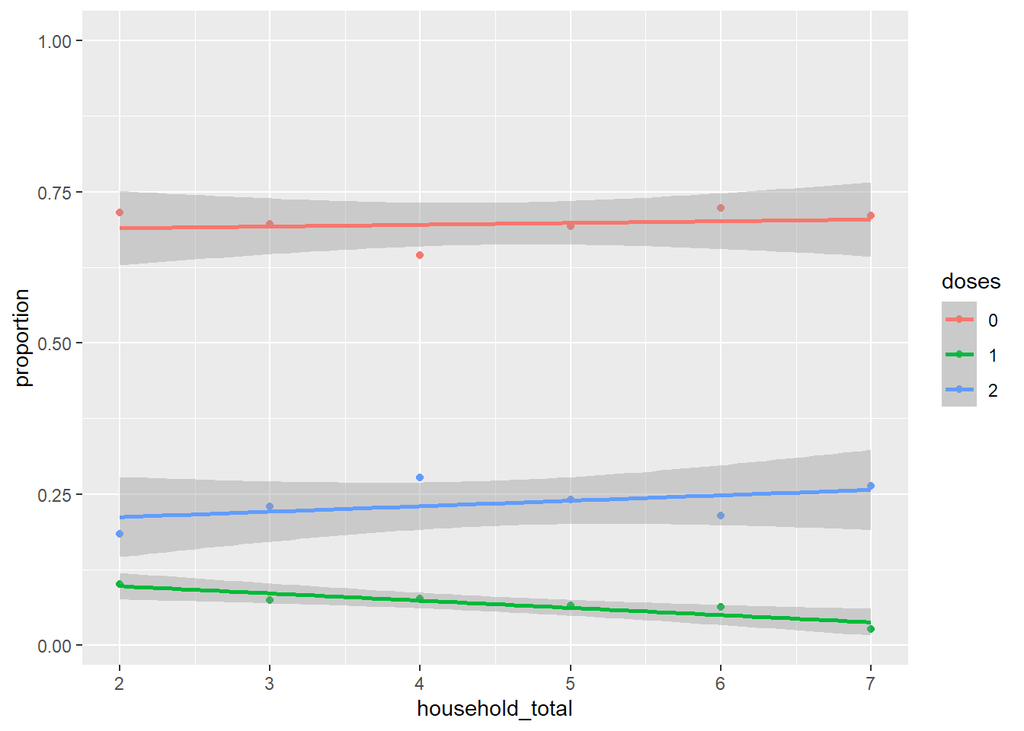

```r
inf_ivd |>
     mutate(influenza_coverage_dosage = factor(influenza_coverage_dosage)) |>

     # stratify by household size and doses received
     filter(household_total > 1 & !is.na(influenza_coverage_dosage)) |>
     mutate(influenza_coverage_dosage = factor(influenza_coverage_dosage)) |>
     group_by(household_total, influenza_coverage_dosage) |>

     # count the number of children in each category
     summarise(count = n()) |>
     reframe(doses = influenza_coverage_dosage, proportion = count/sum(count)) |>
     ggplot(aes(x = household_total, y = proportion, colour = doses)) +
     xlim(2,7) +
     geom_point() +
     geom_smooth(method = "lm")
```

The total number of individuals in a household is not indicative of the proportion of individuals who receive 0 doses of the influenza vaccine.

The proportion of individuals receiving 1 vaccine decreased with an increasing number of individuals in a household whilst The proportion of individuals receiving 2 doses of the influenza vacine increased with an increasing number of individuals in the household.

### Number of aunts and uncles

*Does the number of aunts and uncles a child has affect:* The following is a breakdown of the number of households with respect to the number of aunts and uncles that the child of interest has – for those with a valid covid vaccination status

```r
cov_ivd |>
  filter(!is.na(covid_coverage_age)) |>
  summarise(count = n(), .by = child_auntcles) |>
  arrange(child_auntcles)
```

```
  child_auntcles count
1              0  5423
2              1    26
3              2     7
4              3     2
```

*1. The child’s (covid) vaccination status*

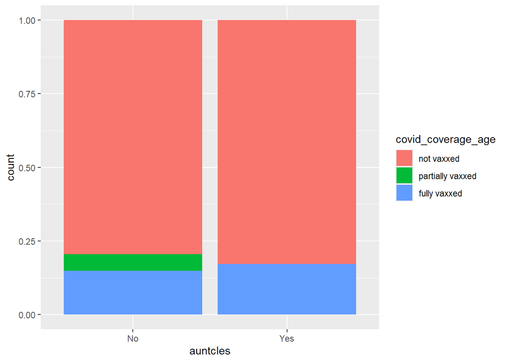

```r
# determine the proportion of individuals who are not, partially and fully vaccinated
# for households of each size
cov_ivd |>
   filter(!is.na(covid_coverage_age)) |>
   mutate(
     auntcles = case_when(
     child_auntcles == 0 ~ "No",
     child_auntcles > 0 ~ "Yes"
     )
   ) |>
   group_by(auntcles, covid_coverage_age) |>
   summarise(count = n()) |>
   ggplot() +
   geom_col(
     aes(x = auntcles, y = count, fill = covid_coverage_age),
     position = "fill"
   ) +
   scale_fill_hue(labels = c("not vaxxed", "partially vaxxed", "fully vaxxed"))
```

Due to the small sample of households where there are both children of interest with valid covid vaccination data and aunts or uncles living with them, let us recatogrise such data to determine if having an aunt or uncle living with a child impacts their chances of receiving the covid vaccine at all

```r
cov_ivd |>
     filter(!is.na(covid_coverage_age)) |>
     mutate(

        # recode for the presence/lack of aunts and uncles
         auntcles = case_when(
             child_auntcles == 0 ~ "No",
             child_auntcles > 0 ~ "Yes"
         ),

         # recode for the presence/lack of any degree of covid coverage
         covid_coverage = case_when(
             covid_coverage_age == 0 ~ "No",
             covid_coverage_age != 0 ~ "Yes"
         )
     ) |>
     group_by(auntcles, covid_coverage) |>
     summarise(count = n()) -> auntcles_cov

# test if uptake of the covid vaccine in children of interest is dependent on
# the presence of aunts and uncles in a houseold
auntcles_cov |>

  # re-frame the data as a contingency table
  (function(x) xtabs(count ~ auntcles + covid_coverage, data = x))() |>

  # carry out a chi-sqaured test
  chisq.test()
```

```
    Pearson's Chi-squared test with Yates' continuity correction

data:  (function(x) xtabs(count ~ auntcles + covid_coverage, data = x))(auntcles_cov)
X-squared = 0.082036, df = 1, p-value = 0.7746
```

*2. The number of doses of the covid vaccine the child receives* Refer to data on the degree of coverage for the covid vaccine with respect to the presence of aunts and uncles

*3. The child’s (influenza) vaccination status* The following is a breakdown of the number of households with respect to the number of aunts and uncles the child of interest has – for those with a valid influenza vaccination status

```r
inf_ivd |>
  filter(!is.na(influenza_coverage_age)) |>
  summarise(count = n(), .by = child_auntcles) |>
  arrange(child_auntcles)
```

```
  child_auntcles count
1              0  5423
2              1    26
3              2     7
4              3     2
```

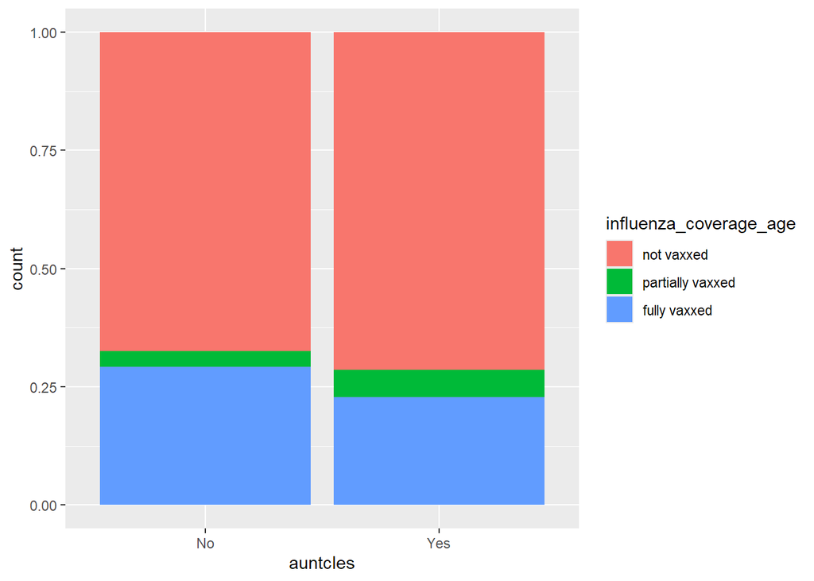

```r
# determine the proportion of individuals who are not, partially and fully vaccinated
# for households of each size
inf_ivd |>
   filter(!is.na(influenza_coverage_age)) |>
   mutate(
     auntcles = case_when(
     child_auntcles == 0 ~ "No",
     child_auntcles > 0 ~ "Yes"
     )
   ) |>
   group_by(auntcles, influenza_coverage_age) |>
   summarise(count = n()) |>
   ggplot() +
   geom_col(
     aes(x = auntcles, y = count, fill = influenza_coverage_age),
     position = "fill"
   ) +
   scale_fill_hue(labels = c("not vaxxed", "partially vaxxed", "fully vaxxed"))
```

To carry out a chi-squared test:

```r
inf_ivd |>
     filter(!is.na(influenza_coverage_age)) |>
     mutate(

         # recode variables for the presence/lack of any uncles
         auntcles = case_when(
             child_auntcles == 0 ~ "No",
             child_auntcles > 0 ~ "Yes"
         ),

         # recode variables for the presence or lack of influenza coverage
         influenza_coverage = case_when(
             influenza_coverage_age == "no coverage" ~ "No",
             influenza_coverage_age != 0 ~ "Yes" # any degree of coverage
         )
     ) |>

     # stratify by degree of coverage and the presence of uncles to get a 2x2
     # contingeny table
     group_by(auntcles, influenza_coverage) |>
     summarise(count = n()) -> auntcles_inf

# determine if there's a relation between influenza vax uptake and the presence
# of aunts and uncles
auntcles_inf |>

  # re-frame the data in a contingency table
  (function(x) xtabs(count ~ influenza_coverage + auntcles, data = x))() |>

  # chi-squared test
  chisq.test()
```

```
    Chi-squared test for given probabilities

data:  (function(x) xtabs(count ~ influenza_coverage + auntcles, data = x))(auntcles_inf)
X-squared = 1734.2, df = 1, p-value < 2.2e-16
```

*4. The number of doses of the influenza vaccine the child receives* Refer to data on the degree of coverage for the influenza vaccine with respect to the presence of aunts and uncles.

### Number of vulnerable individuals

*Does the number of vulnerable individuals living in the same household (this includes individuals who are bedriden, need ventilation and need feeding) affect:*

*The uptake of the covid vaccine?*

```r
cov_ivd |>
  filter(!is.na(covid_coverage_dosage)) |>
  group_by(vulnerable_individuals) |>
  summarise(count = n())
```

```
# A tibble: 4 × 2
  vulnerable_individuals count
                   <int> <int>
1                      0  5421
2                      1    25
3                      2     3
4                      3     9
```

plotting the uptake of the covid vaccine by dosage against the number of vulnerable individuals in a household:

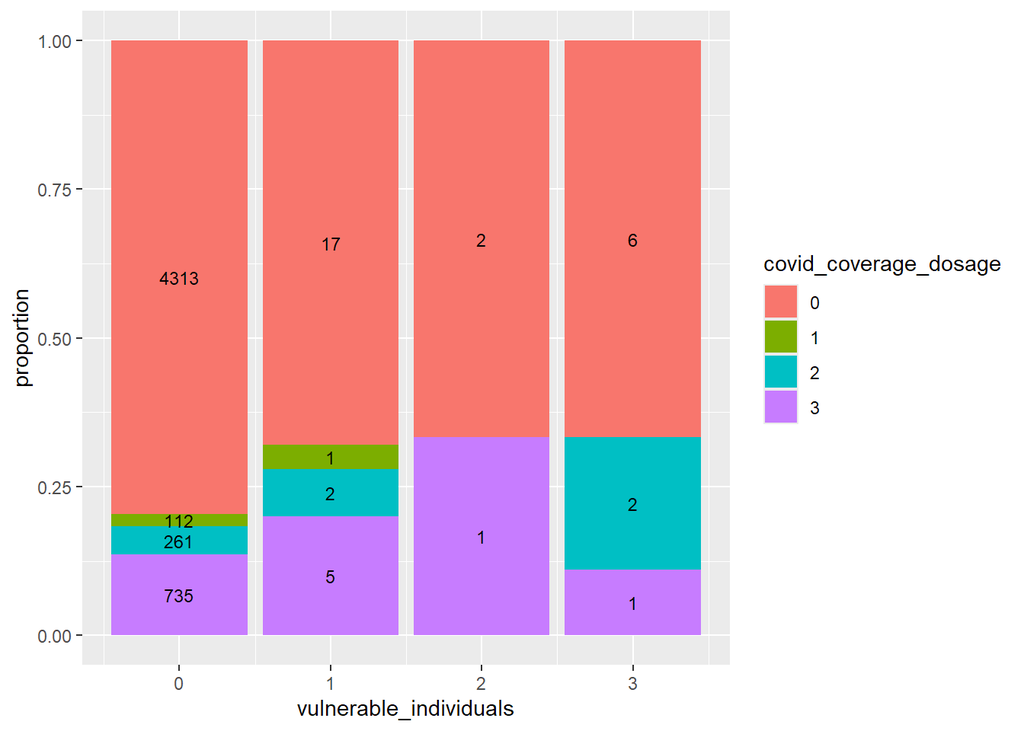

```r
# determine the proportion of individuals who receive 0 to 3 doses
# for households with varying numbers of vulnerable individuals
cov_ivd |>

   # stratify by number of vulnerable individuals and doses received
   filter(!is.na(covid_coverage_dosage)) |>
   mutate(covid_coverage_dosage = factor(covid_coverage_dosage)) |>
   group_by(vulnerable_individuals, covid_coverage_dosage) |>

   # count the number of children in each category
   summarise(count = n()) |>
   ggplot() +
   geom_col(
     aes(x = vulnerable_individuals, y = count, fill = covid_coverage_dosage),
     position = "fill"
   ) +
   geom_text(
     aes(x = vulnerable_individuals, y = count, label = count, group = covid_coverage_dosage),
     position = position_fill(vjust = 0.5),
     size = 3
   ) +
   ylab("proportion")
```

Given the small number of households who have 1 or more vulnerable individuals living with them, let’s reframe this variable to investigate the effect of **the presence** of vulnerable individuals on the number of doses of the covid vaccine the individuals receives.

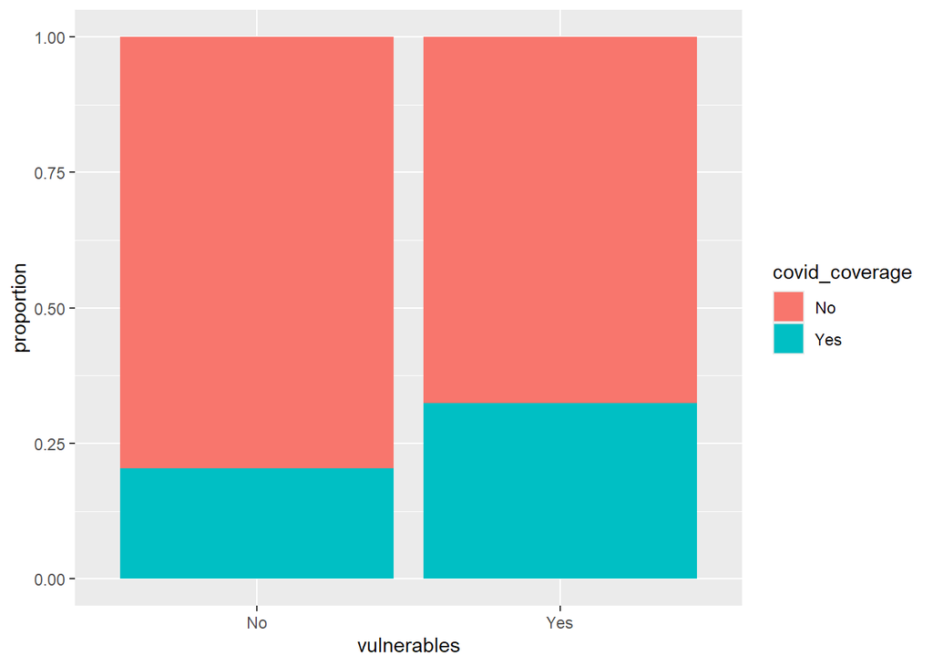

```r
cov_ivd |>

  # filter out eligible individuals
  filter(!is.na(covid_coverage_dosage) & !is.na(vulnerable_individuals)) |>

  mutate(

    # recode according to the presence/lack of any doses of the covid vaccine
    covid_coverage = case_when(
      covid_coverage_dosage == 0 ~ "No",
      covid_coverage_dosage != 0 ~ "Yes"
    ) |>
    factor(),

    # recode according to the presence/lack of any vulnerable individuals
    vulnerables = case_when(
      vulnerable_individuals == 0 ~ "No",
      vulnerable_individuals != 0 ~ "Yes"
    ) |>
    factor()
  ) |>

  # stratify to create 4 categories
  summarise(count = n(), .by = c(vulnerables, covid_coverage)) -> vulnerable_cov

# compare the proportion of individuals who have/haven't received doses of the
# covid vaccine for households with and without vulnerable individuals
vulnerable_cov |>
  mutate(proportion = count/sum(count), .by = vulnerables) |>
  ggplot() +
  geom_col(
    aes(
      x = vulnerables, y = proportion, fill = covid_coverage
      ),
    position = "fill"
  )
```

```r
# perform a chi-sqaured test to determine if there is a correlation between
# the presence of vulnerable individuals and the number of doses of the covid
# vaccine received
vulnerable_cov |>
  # convert the table to a contingency table
  (function(x) xtabs(count ~ vulnerables + covid_coverage, data = x))() |>
    chisq.test()
```

```
    Pearson's Chi-squared test with Yates' continuity correction

data:  (function(x) xtabs(count ~ vulnerables + covid_coverage, data = x))(vulnerable_cov)
X-squared = 2.5474, df = 1, p-value = 0.1105
```

*The uptake of the influenza vaccine* The following is a breakdown of households by the number of vulnerable individuals – for those with children of interest that have valid influenza vaccination data

```r
inf_ivd |>
  filter(!is.na(influenza_coverage_dosage) & !is.na(vulnerable_individuals)) |>
  summarise(count = n(), .by = vulnerable_individuals) |>
  arrange(vulnerable_individuals)
```

```
  vulnerable_individuals count
1                      0  5421
2                      1    25
3                      2     3
4                      3     9
```

plotting the uptake of the influenza vaccine by dosage against the number of vulnerable individuals in a household:

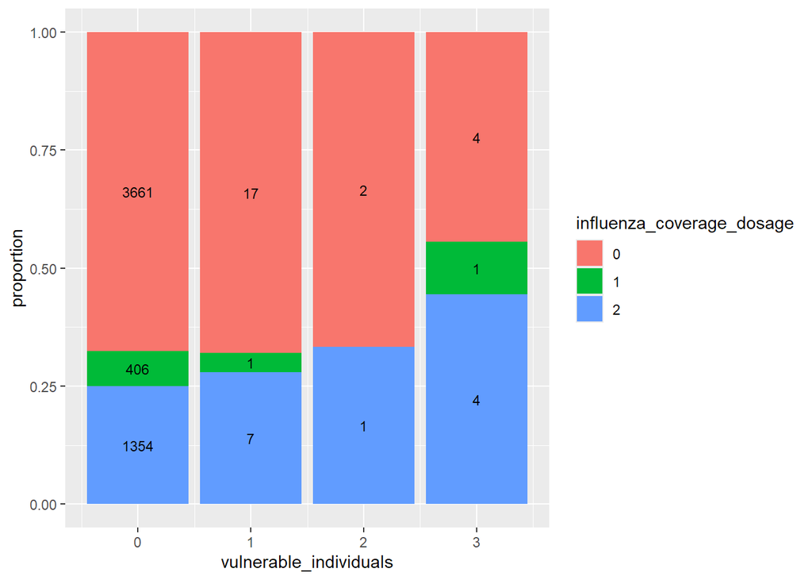

```r
# determine the proportion of individuals who receive 0 to 2 doses
# for households with varying numbers of vulnerable individuals
inf_ivd |>

   # stratify by number of vulnerable individuals and doses received
   filter(!is.na(influenza_coverage_dosage)) |>
   mutate(influenza_coverage_dosage = factor(influenza_coverage_dosage)) |>
   group_by(vulnerable_individuals, influenza_coverage_dosage) |>

   # count the number of children in each category
   summarise(count = n()) |>
   ggplot() +
   geom_col(
     aes(x = vulnerable_individuals, y = count, fill = influenza_coverage_dosage),
     position = "fill"
   ) +
   geom_text(
     aes(x = vulnerable_individuals, y = count, label = count, group = influenza_coverage_dosage),
     position = position_fill(vjust = 0.5),
     size = 3
   ) +
   ylab("proportion")
```

An increase in the number of vulnerable individuals in a household seems to be indicative of an increase in the proportion of children of interest who receive 2 doses oef the influenza vaccine. However,the sample size is not statistically significant. (n = 3 for households with 2 vulnerable individuals; and n = 9 for households with 3 vulnerable individuals).

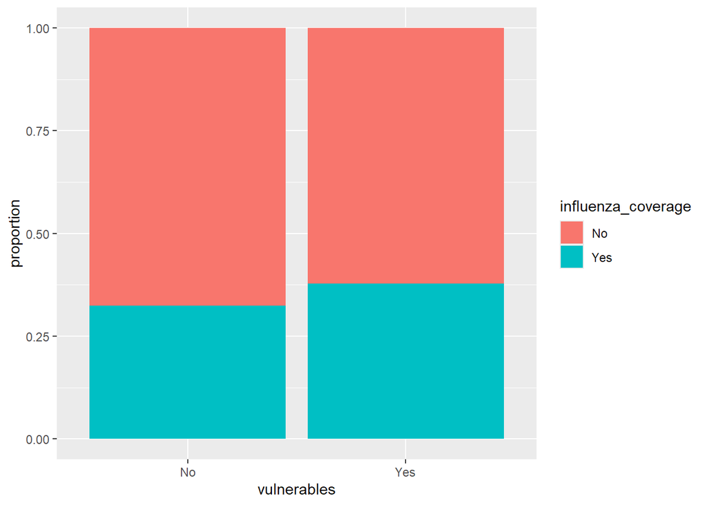

```r
inf_ivd |>

  # filter out eligible individuals
  filter(!is.na(influenza_coverage_dosage) & !is.na(vulnerable_individuals)) |>

  mutate(

    # recode according to the presence/lack of any doses of the influenza vaccine
    influenza_coverage = case_when(
      influenza_coverage_dosage == 0 ~ "No",
      influenza_coverage_dosage != 0 ~ "Yes"
    ) |>
    factor(),

    # recode according to the presence/lack of any vulnerable individuals
    vulnerables = case_when(
      vulnerable_individuals == 0 ~ "No",
      vulnerable_individuals != 0 ~ "Yes"
    ) |>
    factor()
  ) |>

  # stratify to create 4 categories
  summarise(count = n(), .by = c(vulnerables, influenza_coverage)) ->
  vulnerable_inf

# compare the proportion of individuals who have/haven't received doses of the
# influenza vaccine for households with and without vulnerable individuals
vulnerable_inf |>
  mutate(proportion = count/sum(count), .by = vulnerables) |>
  ggplot() +
  geom_col(
    aes(
      x = vulnerables, y = proportion, fill = influenza_coverage
      ),
    position = "fill"
  )
```

```r
# perform a chi-sqaured test to determine if there is a correlation between
# the presence of vulnerable individuals and the number of doses of the influenza
# vaccine received
vulnerable_inf |>
  # convert the table to a contingency table
  (function(x) xtabs(count ~ vulnerables + influenza_coverage, data = x))() |>
    chisq.test()
```

```
    Pearson's Chi-squared test with Yates' continuity correction

data:  (function(x) xtabs(count ~ vulnerables + influenza_coverage,     data = x))(vulnerable_inf)
X-squared = 0.26948, df = 1, p-value = 0.6037
```

Performing a chi-squared test, as the p-value > 0.05 (p = 0.6037). Thus, we have insufficient evidence to reject the null and cannot conclude that the proportion of children of interest receiving a dose of the influenza vaccine is not independent of the presence of vulnerable individuals in their household.

### Number of grandparents

*Does the number of grandparents living in the same household affect:* *1. The number of doses of the covid vaccine the child receives* The following is a breakdown of the households by the number of grandparents per household

```r
cov_ivd |>

  filter(!is.na(covid_coverage_dosage) & !is.na(child_grand)) |>
  summarise(count = n(), .by = child_grand) |>
  arrange(child_grand)
```

```
  child_grand count
1           0  5116
2           1   147
3           2   174
4           3    11
5           4    10
```

let us plot the proportion of children of interest with different covid vaccination statuses for households 0 to 4 grandparents.

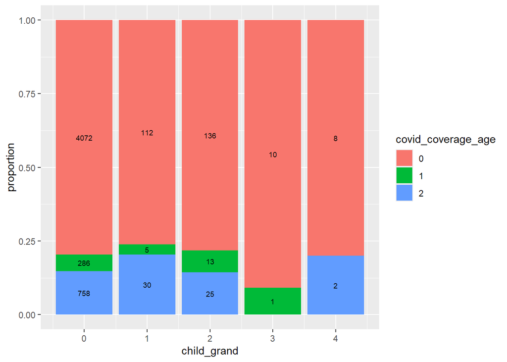

```r
cov_ivd |>
  filter(!is.na(covid_coverage_age) & !is.na(child_grand)) |>
  summarise(count = n(), .by = c(covid_coverage_age, child_grand)) |>
  mutate(proportion = count/sum(count), .by = child_grand) -> grand_cov_age

# plot how the number of grandparents in a household affects the covid coverage
# by age
grand_cov_age |>

  # create proportion bar plots to reflect the proportion of children who are
  # fully, partially and not covered by the covid vaccine
  ggplot() +
  geom_col(aes(x = child_grand, y = proportion, fill = covid_coverage_age), position = "fill") +
  geom_text(
    aes(x = child_grand, y = count, label = count, group = covid_coverage_age),  # Ensure text aligns with each segment
    position = position_fill(vjust = 0.5),  # Centers text inside each stacked section
    size = 2.5
  )
```

An increase in the number of grandparents in a household does not have a significant impact on the proportion of children of interest who receive full coverage with the covid vaccine.

Running linear regressions to determine how the proportions for each degree of covid coverage vary with the number of grandparents in a household, we obtain the following models.

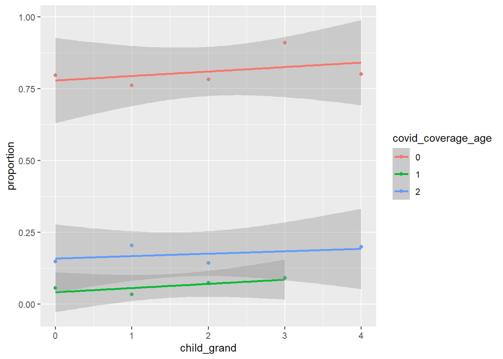

```r
# create variable to hold linear models
lms_grand_cov_age <- NA

# grand_cov_age$covid_coverage_age <- as.numeric(grand_cov_age$covid_coverage_age)

# calculate coefficients for linear models
for(i in 1:3) {
grand_cov_age[grand_cov_age$covid_coverage_age == unique(grand_cov_age$covid_coverage_age)[i], ] |>
    (function(x) lm(proportion ~ child_grand, data = x))() -> y
lms_grand_cov_age[i + 1] <- y
}

# plot linear models
grand_cov_age |>
  ggplot(aes(x = child_grand, y = proportion)) +
  geom_point(aes(colour = covid_coverage_age)) +
  geom_smooth(aes(colour = covid_coverage_age), method = "lm")
```

```r
## names(lms_grand_cov_age) <- c("no coverage", "partial coverage", "full coverage")
lms_grand_cov_age
```

```
[[1]]
[1] NA

[[2]]
(Intercept) child_grand
 0.77864434  0.01553175

[[3]]
(Intercept) child_grand
0.159265861 0.008408425

[[4]]
(Intercept) child_grand
 0.04202702  0.01457172
```

Now, examining how the **presence** of grandparents (0 vs more than 0) affects the uptake of the covid vaccine

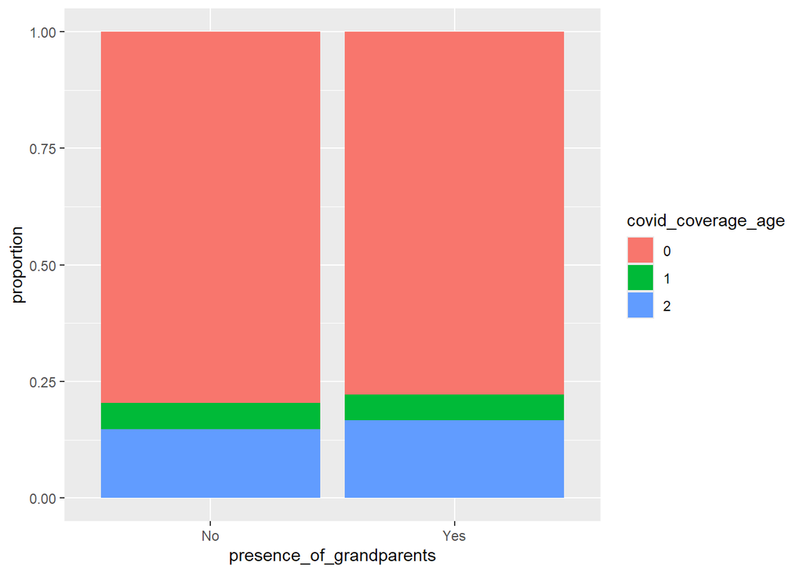

```r
cov_ivd |>
  filter(!is.na(covid_coverage_age) & !is.na(child_grand)) |>
  mutate(
    presence_of_grandparents = case_when(
      child_grand == 0 ~ "No",
      child_grand > 0 ~ "Yes"
    )
  ) |>
  summarise(count = n(), .by = c(covid_coverage_age, presence_of_grandparents)) |>
  mutate(proportion = count/sum(count), .by = presence_of_grandparents) ->  grand_presence_covid_age

grand_presence_covid_age |>
ggplot() +
  geom_col(aes(x = presence_of_grandparents, y = proportion, fill = covid_coverage_age), position = "fill")
```

There is no appreciable difference in the proportion of children (of interest) getting vaccinated with the covid vaccine in households where there is and isnt a grandparent present

*Does the number of grandparents living in the same household affect:* *2. The number of doses of the influenza vaccine the child receives*

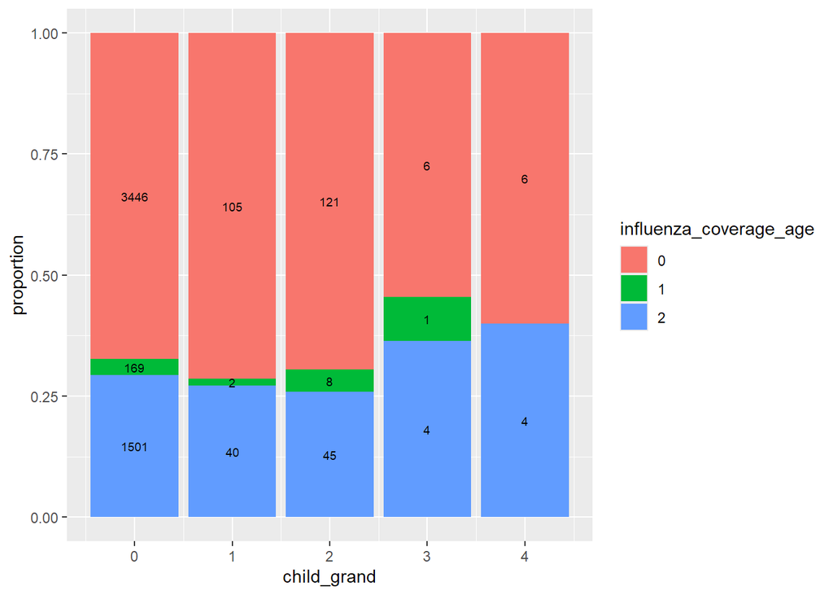

```r
inf_ivd |>
  filter(!is.na(influenza_coverage_age) & !is.na(child_grand)) |>
  summarise(count = n(), .by = c(influenza_coverage_age, child_grand)) -> grand_inf_age

# plot how the number of grandparents in a household affects the influenza coverage
# by age
grand_inf_age |>
    mutate(proportion = count/sum(count), .by = child_grand) |>

  # create proportion bar plots to reflect the proportion of children who are
  # fully, partially and not covered by the covid vaccine
  ggplot() +
  geom_col(aes(x = child_grand, y = proportion, fill = influenza_coverage_age), position = "fill") +
  geom_text(
    aes(x = child_grand, y = count, label = count, group = influenza_coverage_age),  # Ensure text aligns with each segment
    position = position_fill(vjust = 0.5),  # Centers text inside each stacked section
    size = 2.5
  )
```

```r
# plot a table showing the numbers corresponding to the graph above
grand_inf_age |>
  arrange(child_grand, influenza_coverage_age)
```

```
   influenza_coverage_age child_grand count
1                       0           0  3446
2                       1           0   169
3                       2           0  1501
4                       0           1   105
5                       1           1     2
6                       2           1    40
7                       0           2   121
8                       1           2     8
9                       2           2    45
10                      0           3     6
11                      1           3     1
12                      2           3     4
13                      0           4     6
14                      2           4     4
```

Does the presence of grandparents affect the uptake of the influenza vaccine in children of interest?

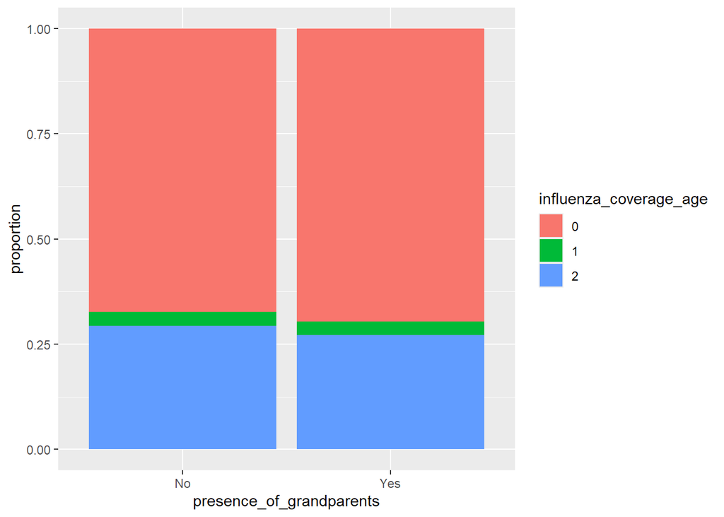

```r
inf_ivd |>
  filter(!is.na(influenza_coverage_age) & !is.na(child_grand)) |>
  mutate(
    presence_of_grandparents = case_when(
      child_grand == 0 ~ "No",
      child_grand > 0 ~ "Yes"
    )
  ) |>
  summarise(count = n(), .by = c(influenza_coverage_age, presence_of_grandparents)) |>
  mutate(proportion = count/sum(count), .by = presence_of_grandparents) ->  grand_presence_influenza_age

grand_presence_influenza_age |>
ggplot() +
  geom_col(aes(x = presence_of_grandparents, y = proportion, fill = influenza_coverage_age), position = "fill")
```

## Child and siblings

### Total number of siblings

The following is a breakdown of the number of households by number of: 1) number of siblings

```r
ivd |>
  filter(!is.na(child_siblings)) |>
  summarise(count = n(), .by = child_siblings) |>
  arrange(child_siblings)
```

```
  child_siblings count
1              0  2442
2              1  2467
3              2   621
4              3    91
5              4    15
```

2. number of brothers

```r
ivd |>
  filter(!is.na(child_siblings)) |>
  summarise(count = n(), .by = child_brothers) |>
  arrange(child_brothers)
```

```
  child_brothers count
1              0  3778
2              1  1624
3              2   215
4              3    18
5              4     1
```

3. number of sisters

```r
ivd |>
  filter(!is.na(child_siblings)) |>
  summarise(count = n(), .by = child_sisters) |>
  arrange(child_sisters)
```

```
  child_sisters count
1             0  3925
2             1  1507
3             2   190
4             3    13
5             4     1
```

*Does the number of siblings living with the child in the same household affect:*

*1.The uptake of the covid vaccine in children of interest*

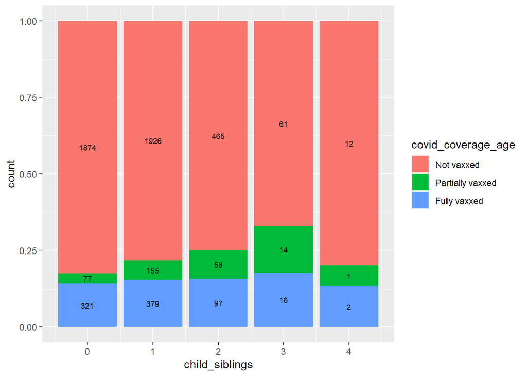

```r
cov_ivd |>
  filter(!is.na(covid_coverage_age) & !is.na(child_siblings)) |>
  summarise(count = n(), .by = c(covid_coverage_age, child_siblings)) |>
  mutate(
      covid_coverage_age = factor(
        case_when(
        covid_coverage_age == 0 ~ "Not vaxxed",
        covid_coverage_age == 1 ~ "Partially vaxxed",
        covid_coverage_age == 2 ~ "Fully vaxxed"
        ),
        levels = c("Not vaxxed", "Partially vaxxed", "Fully vaxxed")
      )
    ) ->
siblings_cov_age

siblings_cov_age |>
  ggplot() +
  geom_col(
    aes(x = child_siblings, y = count, fill = covid_coverage_age), position = "fill"
  ) +
  geom_text(
    aes(x = child_siblings, y = count, label = count, group = covid_coverage_age),  # Ensure text aligns with each segment
    position = position_fill(vjust = 0.5),  # Centers text inside each stacked section
    size = 2.5
  )
```

Now, examining if the presence of siblings instead of the number of siblings affects the uptake of the covid vaccine in children of interest

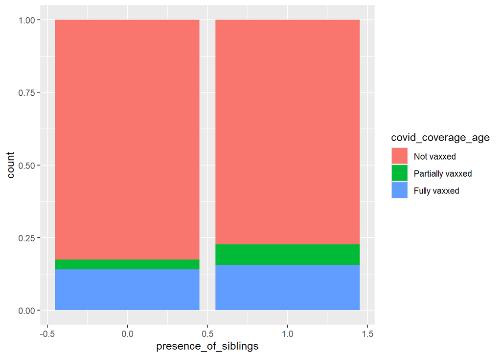

```r
siblings_cov_age |>
  mutate(
    presence_of_siblings = case_when(
      child_siblings == 0 ~ 0,
      child_siblings > 0 ~ 1
    )
  ) |>
  ggplot() +
  geom_col(
    aes(x = presence_of_siblings, y = count, fill = covid_coverage_age), position = "fill"
  )
```

*2. The uptake of the Influenza vaccine in children of interest*

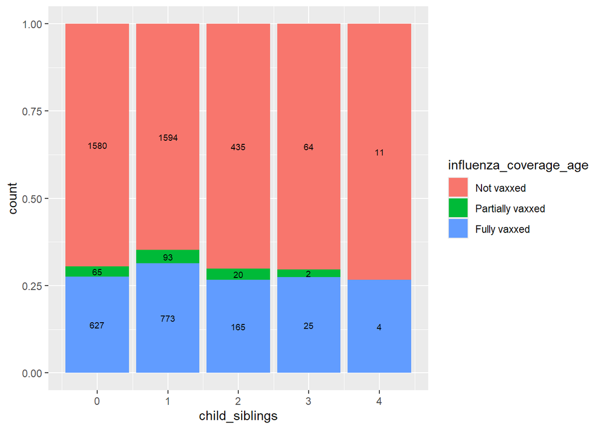

```r
inf_ivd |>
  filter(!is.na(influenza_coverage_age) & !is.na(child_siblings)) |>
  summarise(count = n(), .by = c(influenza_coverage_age, child_siblings)) |>
  mutate(
      influenza_coverage_age = factor(
        case_when(
        influenza_coverage_age == 0 ~ "Not vaxxed",
        influenza_coverage_age == 1 ~ "Partially vaxxed",
        influenza_coverage_age == 2 ~ "Fully vaxxed"
        ),
        levels = c("Not vaxxed", "Partially vaxxed", "Fully vaxxed")
      )
    ) -> siblings_inf_age

siblings_inf_age |>
  ggplot() +
  geom_col(
    aes(x = child_siblings, y = count, fill = influenza_coverage_age), position = "fill"
  ) +
  geom_text(
    aes(x = child_siblings, y = count, label = count, group = influenza_coverage_age),  # Ensure text aligns with each segment
    position = position_fill(vjust = 0.5),  # Centers text inside each stacked section
    size = 2.5
  )
```

Now, examining if the presence of siblings instead of the number of siblings affects the uptake of the influenza vaccine in children of interest

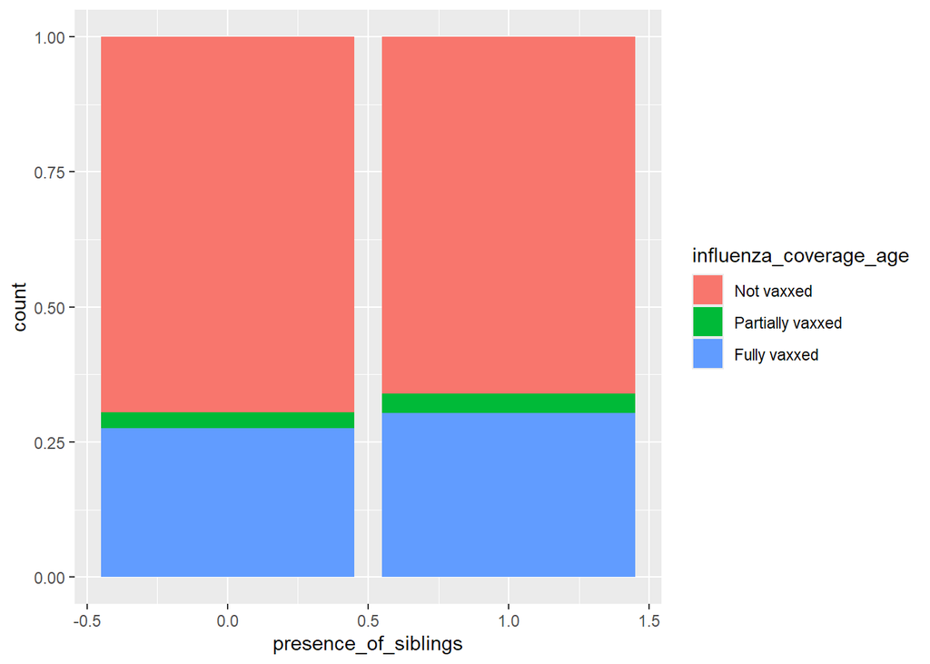

```r
siblings_inf_age |>
  mutate(
    presence_of_siblings = case_when(
      child_siblings == 0 ~ 0,
      child_siblings > 0 ~ 1
    )
  ) |>
  ggplot() +
  geom_col(
    aes(x = presence_of_siblings, y = count, fill = influenza_coverage_age), position = "fill"
  )
```

### Number of brothers and/or sisters

*Does the number of sisters and or brothers living in the same household as the child affect:* *1. The uptake of the covid vaccine(by coverage) in children of interest*

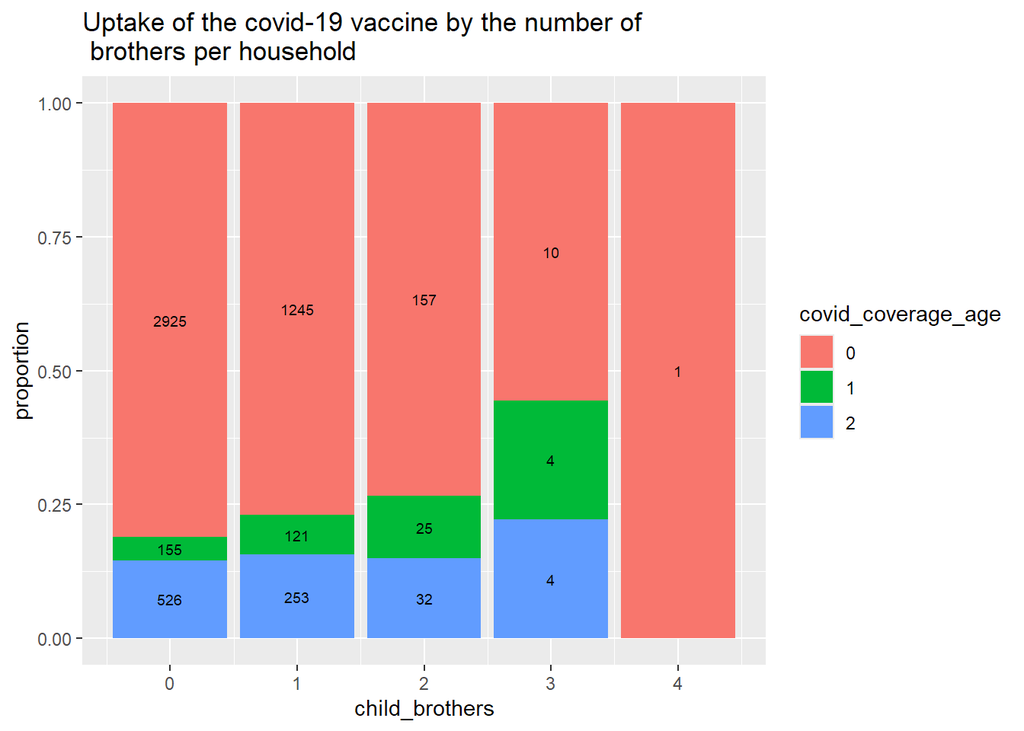

```r
cov_ivd |>
  filter(!is.na(covid_coverage_age) & !is.na(child_brothers)) |>
  summarise(count = n(), .by = c(covid_coverage_age, child_brothers)) |>
  mutate(proportion = count / sum(count), .by = child_brothers) -> cov_coverage_age_brothers

cov_ivd |>
  filter(!is.na(covid_coverage_age) & !is.na(child_sisters)) |>
  summarise(count = n(), .by = c(covid_coverage_age, child_sisters)) |>
  mutate(proportion = count / sum(count), .by = child_sisters) -> cov_coverage_age_sisters

cov_ivd |>
  filter(!is.na(covid_coverage_age) & child_brothers <= 3 & child_sisters <= 3) |>
  summarise(count = n(), .by = c(covid_coverage_age, child_sisters, child_brothers)) |>
  mutate(proportion = count / sum(count), .by = c(child_sisters, child_brothers)) -> cov_covereage_age_brothers_sisters

cov_coverage_age_brothers |>
  ggplot() +
  geom_col(aes(x = child_brothers, y = proportion, fill = covid_coverage_age), position = "fill") +
  geom_text(aes(x = child_brothers, y = proportion, label = count, group = covid_coverage_age), position = position_fill(vjust = 0.5), size = 2.5) +
  ggtitle("Uptake of the covid-19 vaccine by the number of \n brothers per household")
```

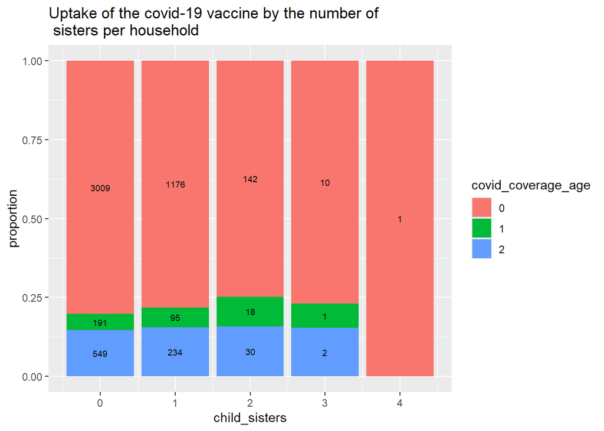

```r
cov_coverage_age_sisters |>
  ggplot() +
  geom_col(aes(x = child_sisters, y = proportion, fill = covid_coverage_age), position = "fill") +
  geom_text(aes(x = child_sisters, y = proportion, label = count, group = covid_coverage_age), position = position_fill(vjust = 0.5), size = 2.5) +
  ggtitle("Uptake of the covid-19 vaccine by the number of \n sisters per household")
```

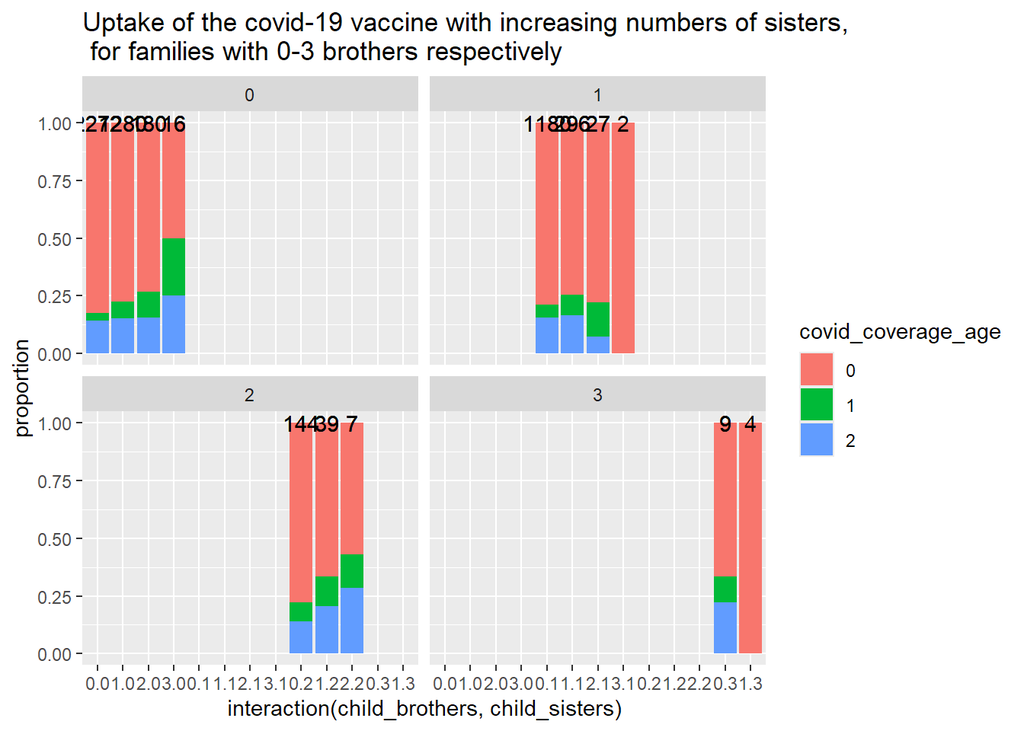

```r
cov_covereage_age_brothers_sisters |>
  mutate(sum_by_brothers = sum(count), .by = c(child_brothers, child_sisters)) |>
  ggplot() +
  geom_col(aes(x = interaction(child_brothers, child_sisters), y = proportion, fill = covid_coverage_age), position = "fill") +
  geom_text(aes(x = interaction(child_brothers, child_sisters), y = 1, label = sum_by_brothers)) +
  facet_wrap(vars(child_sisters)) +
  ggtitle("Uptake of the covid-19 vaccine with increasing numbers of sisters, \n for families with 0-3 brothers respectively")
```